# MATH 3910_Linear Regression Analysis

# Principal Component Regression

Principal component regression only works on quantitative variables, not categorical ones. It works by finding linear combinations of predictors (components) that maximizes the variance of the data, then performs regular least-squares linear regression on the components. We fit on `ntrain` only, since that is the data frame with the quantitative predictors.

First, we generate the random training (and testing) data from `ntrain`.

```r
ntrain = na.omit(ntrain) # Should omit nothing since we already removed NAs
n= nrow(ntrain)
train_samp = sample(n,round(.8*n))
```

Perform the fit.

```r
pcr_fit = pcr(SalePrice~.,data=ntrain, scale=TRUE,validation = "CV", subset = train_samp)
```

Produce the validation plot. This shows the error against the number of components used.

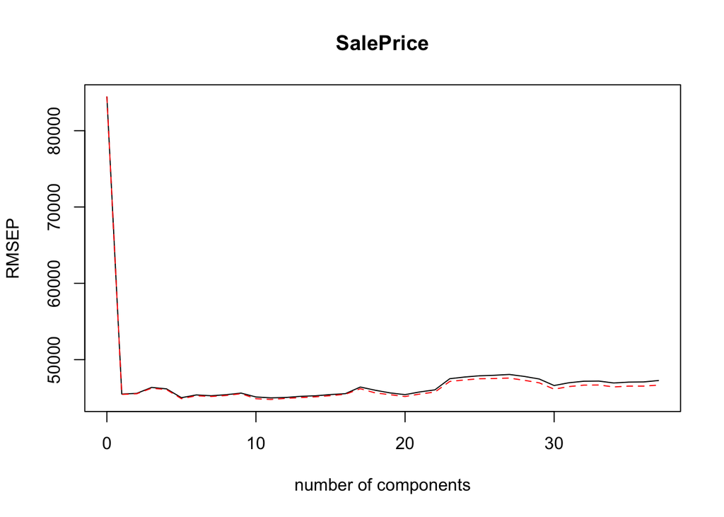

```r
validationplot(pcr_fit,val.type = "RMSEP")
```

We see that the error drops significantly at the inclusion of one component, then gradually increases with the introduction of more. From the plot, 5 seems like a good number of components to include. It is a simple model that produces a relatively low error.

Finally, we fit and get the error produced when using 5 components.

```r
#Prepare data; must be a matrix for this model
x = model.matrix(SalePrice~.,ntrain)[,-1]
index <- match("SalePrice", names(ntrain))
y=ntrain[,index]

# predict
pcr_pred = predict(pcr_fit,x[-train_samp,],ncomp = 5)  #pick the number of components

# Get the error
error3 = sqrt(sum((pcr_pred-y[-train_samp])^2))
error3
```

```
## [1] 442769.5
```

# The Lasso

The lasso uses a modified version of least squares regression; it penalizes large predictors and can set some predictors to 0. Here, we use the lasso with cross-validation. We fit on the training data, predict on the test data, and get the test error. We use the best value of $\lambda$ (the one that minimizes test error) to perform our final fit.

First, we reset our model matrix to include the categorical variables as well.

```r
#Prepare data; must be a matrix for this model
x = model.matrix(SalePrice~.,train_final)[,-1]
index <- match("SalePrice", names(train_final))
y=train_final[,index]
```

Here, we apply the lasso and plot the error each value of $\lambda$ produces.

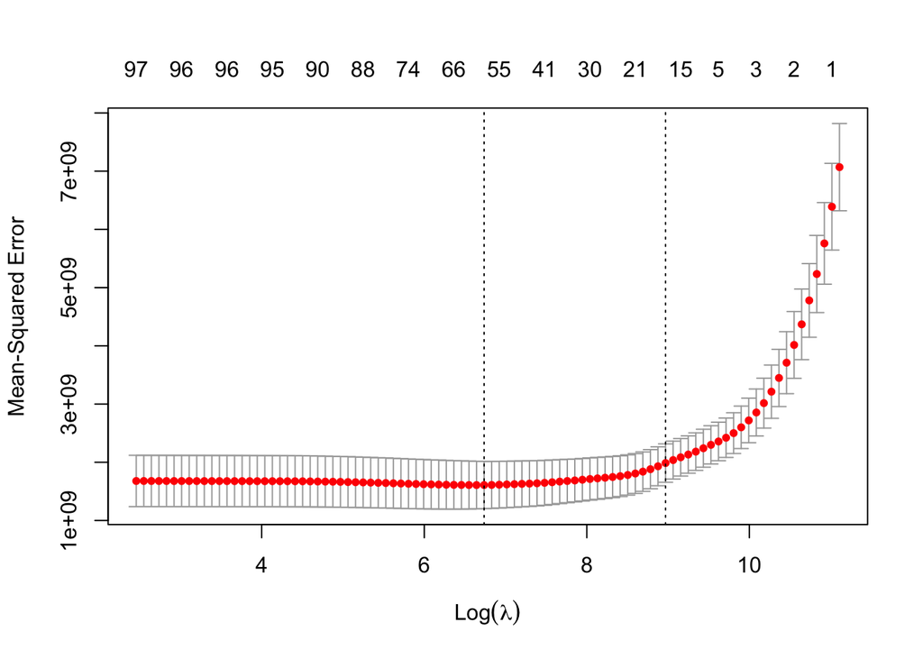

```r
cv_lasso = cv.glmnet(x[train_samp,],y[train_samp],alpha = 1)

plot(cv_lasso)
```

Finally, we fit using the best value of $\lambda$ and produce the test error.

```r
best_lam = cv_lasso$lambda.min

lasso_mod = glmnet(x[train_samp,],y[train_samp],alpha = 1,lambda = best_lam) # alpha = 0 gives ridge regression

lasso_pred = predict(lasso_mod,s = best_lam, newx = x[-train_samp,])

error4 <- sqrt(sum((lasso_pred-y[-train_samp])^2))
error4
```

```
## [1] 351827.9
```

# Ridge Regression

Ridge regression also uses a modified version of least squares regression (though the penalty is different than the lasso’s penalty); it penalizes large predictors and but cannot set some predictors to 0. Here, we use ridge regression with cross-validation. We fit on the training data, predict on the test data, and get the test error. We use the best value of $\lambda$ (the one that minimizes test error) to perform our final fit.

Here, we apply ridge regression and plot the error each value of $\lambda$ produces.

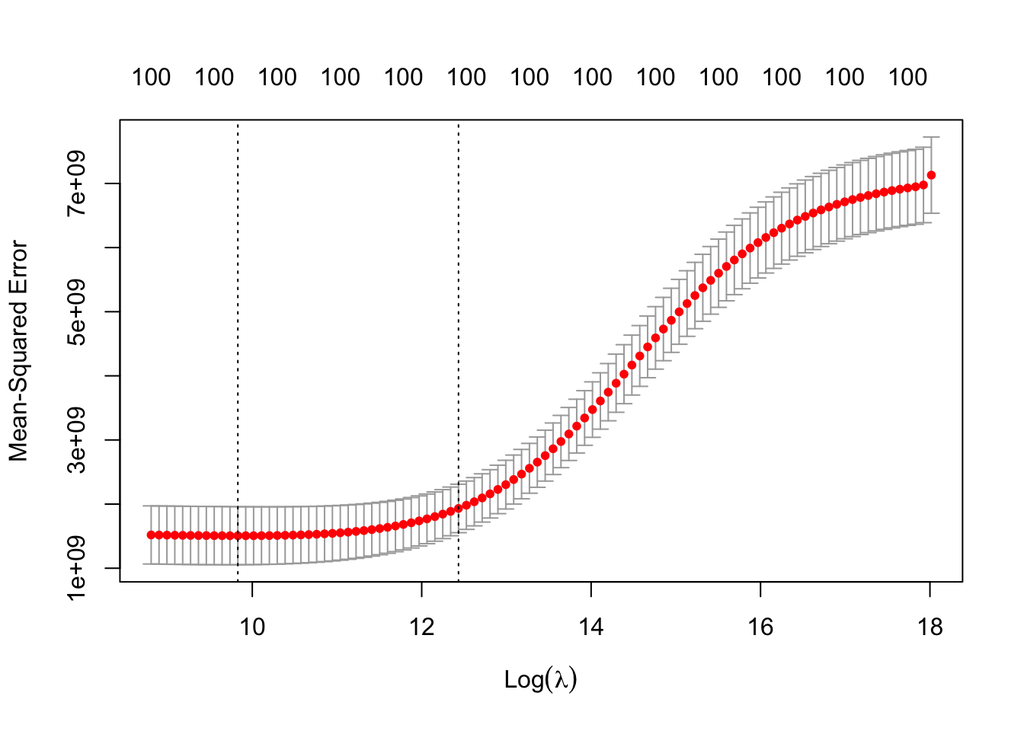

```r
cv_ridge = cv.glmnet(x[train_samp,],y[train_samp],alpha = 0)

plot(cv_ridge)
```

We use the best value of $\lambda$ to fit and produce test error.

```r
best_lam = cv_ridge$lambda.min

ridge_mod = glmnet(x[train_samp,],y[train_samp],alpha = 0,lambda = best_lam) # alpha = 0 gives ridge regression

ridge_pred = predict(ridge_mod,s = best_lam, newx = x[-train_samp,])

error5 <- sqrt(sum((ridge_pred-y[-train_samp])^2))
error5
```

```
## [1] 338255.2
```

# Conclusion

These are the errors produced by each model.

```r
# Full fit, backwards stepwise, PCR, Lasso, Ridge Regression
error_list = c(error1, error2, error3, error4, error5)
error_list
```

```
## [1] 926598.1 835140.6 442769.5 351827.9 338255.2
```

To further assess the fit of each model, we can plot the errors against the true value of `SalePrice` for the testing data. Models that produce errors constant and near 0 are more effective.

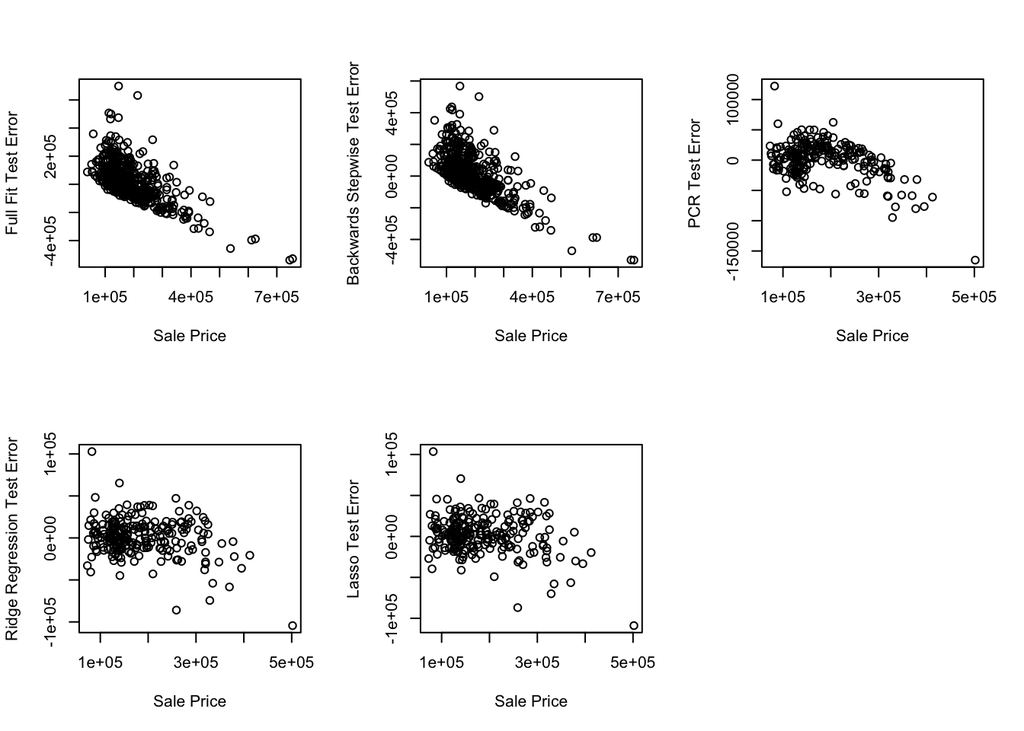

```r
par(mfrow = c(2,3))
plot(SalePrice[-train_samp],full_pred-SalePrice[-train_samp],xlab="Sale Price",ylab="Full Fit Test Error")
plot(SalePrice[-train_samp],bwd_pred-SalePrice[-train_samp],xlab="Sale Price",ylab="Backwards Stepwise Test Error")
plot(y[-train_samp],pcr_pred-y[-train_samp],xlab="Sale Price",ylab="PCR Test Error")
plot(y[-train_samp],ridge_pred-y[-train_samp],xlab="Sale Price",ylab="Ridge Regression Test Error")
plot(y[-train_samp],lasso_pred-y[-train_samp],xlab="Sale Price",ylab="Lasso Test Error")
```

From the plots of error, it is clear that the full fit and the backwards stepwise fit missed structure in the data, resulting in relatively high errors. PCR produced smaller error, but there is still some structure to the error plot. Ridge regression and the lasso captured the most structure, and therefore produced the smallest error. In summary, ridge regression is the best model for this data.

## Kaggle Prediction

Now that we have our best model, we will test on the Kaggle testing data.

```r
test <- data.frame(fread("home-data-for-ml-course/test.csv")) # Load in testing data
dim(test)
```

```
## [1] 1459   80
```

Now process the data to remove NAs in the same way we processed the training data.

We create `ntrain`, a data frame with only quantitative data.

```r
ntest<-test[, sapply(test, class) != 'character']
names(ntest)
```

```
##  [1] "Id"            "MSSubClass"    "LotFrontage"   "LotArea"
##  [5] "OverallQual"   "OverallCond"   "YearBuilt"     "YearRemodAdd"
##  [9] "MasVnrArea"    "BsmtFinSF1"    "BsmtFinSF2"    "BsmtUnfSF"
## [13] "TotalBsmtSF"   "X1stFlrSF"     "X2ndFlrSF"     "LowQualFinSF"
## [17] "GrLivArea"     "BsmtFullBath"  "BsmtHalfBath"  "FullBath"
## [21] "HalfBath"      "BedroomAbvGr"  "KitchenAbvGr"  "TotRmsAbvGrd"
## [25] "Fireplaces"    "GarageYrBlt"   "GarageCars"    "GarageArea"
## [29] "WoodDeckSF"    "OpenPorchSF"   "EnclosedPorch" "X3SsnPorch"
## [33] "ScreenPorch"   "PoolArea"      "MiscVal"       "MoSold"
## [37] "YrSold"
```

Now we will replace NAs with the mean.

```r
for (mm in 1:ncol(ntest)){
  ntest[,mm]<-replace_na(ntest[,mm],mean(na.omit(ntest[,mm])))
}

#colSums(is.na(ntest)) # Make sure there are no more NAs
```

`ctrain` is created with only categorical data.

```r
ctest<-test[, sapply(test, class) == 'character']
names(ctest)
```

```
##  [1] "MSZoning"      "Street"        "Alley"         "LotShape"
##  [5] "LandContour"   "Utilities"     "LotConfig"     "LandSlope"
##  [9] "Neighborhood"  "Condition1"    "Condition2"    "BldgType"
## [13] "HouseStyle"    "RoofStyle"     "RoofMatl"      "Exterior1st"
## [17] "Exterior2nd"   "MasVnrType"    "ExterQual"     "ExterCond"
## [21] "Foundation"    "BsmtQual"      "BsmtCond"      "BsmtExposure"
## [25] "BsmtFinType1"  "BsmtFinType2"  "Heating"       "HeatingQC"
## [29] "CentralAir"    "Electrical"    "KitchenQual"   "Functional"
## [33] "FireplaceQu"   "GarageType"    "GarageFinish"  "GarageQual"
## [37] "GarageCond"    "PavedDrive"    "PoolQC"        "Fence"
## [41] "MiscFeature"   "SaleType"      "SaleCondition"
```

We cut down the variables to those deemed useful earlier.

```r
# These variables below didn't have too many NAs and they weren't too uniform

usefulones = c("MSZoning","LotShape","Neighborhood","MasVnrType","ExterQual","Foundation","BsmtQual","BsmtExposure","BsmtFinType1","KitchenQual","GarageType","GarageFinish")

# Make the data in ctrain factors
ctest[] <- lapply(ctest, factor) # the "[]" keeps the dataframe structure
col_names <- names(ctest)
# do do it for some names in a vector named 'col_names'
ctest[col_names] <- lapply(ctest[col_names] , factor)

# Select only the preferred
ctest<- ctest[,usefulones]

ctest  <- ctest %>% mutate(Id = ntest$Id)
```

Now we replace the NAs in the categorical data with the mode.

```r
for (mm in 1:ncol(ctest)){

  uniqx <- unique(ctest[,mm])
  uniqx
  md = uniqx[which.max(tabulate(match(ctest[,mm], uniqx)))]
  ctest[,mm]<-replace_na(ctest[,mm],md)

}

#colSums(is.na(ctest)) # Make sure there are no more NAs
```

Finally, merge the data.

```r
test_final <- data.frame(merge(ntest,ctest,by="Id"))
dim(test_final)
```

```
## [1] 1459   49
```

```r
sapply(test_final,class) # Check that our data types are "numeric" and "factor"
```

```
##            Id    MSSubClass   LotFrontage       LotArea   OverallQual
##     "numeric"     "numeric"     "numeric"     "numeric"     "numeric"
##   OverallCond     YearBuilt  YearRemodAdd    MasVnrArea    BsmtFinSF1
##     "numeric"     "numeric"     "numeric"     "numeric"     "numeric"
##    BsmtFinSF2     BsmtUnfSF   TotalBsmtSF     X1stFlrSF     X2ndFlrSF
##     "numeric"     "numeric"     "numeric"     "numeric"     "numeric"
##  LowQualFinSF     GrLivArea  BsmtFullBath  BsmtHalfBath      FullBath
##     "numeric"     "numeric"     "numeric"     "numeric"     "numeric"
##      HalfBath  BedroomAbvGr  KitchenAbvGr  TotRmsAbvGrd    Fireplaces
##     "numeric"     "numeric"     "numeric"     "numeric"     "numeric"
##   GarageYrBlt    GarageCars    GarageArea    WoodDeckSF   OpenPorchSF
##     "numeric"     "numeric"     "numeric"     "numeric"     "numeric"
## EnclosedPorch    X3SsnPorch   ScreenPorch      PoolArea       MiscVal
##     "numeric"     "numeric"     "numeric"     "numeric"     "numeric"
##        MoSold        YrSold      MSZoning      LotShape  Neighborhood
##     "numeric"     "numeric"      "factor"      "factor"      "factor"
##    MasVnrType     ExterQual    Foundation      BsmtQual  BsmtExposure
##      "factor"      "factor"      "factor"      "factor"      "factor"
##  BsmtFinType1   KitchenQual    GarageType  GarageFinish
##      "factor"      "factor"      "factor"      "factor"
```

Perform the prediction using ridge regression, our best model.

```r
x_test = model.matrix(~.,test_final)[,-1]
ridge_pred_test = predict(ridge_mod,s = best_lam, newx = x_test)
mean(ridge_pred_test)
```

```
## [1] 176625.9
```

```r
mean(SalePrice)
```

```
## [1] 180921.2
```

This mean sale price predicted by our model on the testing data is about 177,000 dollars, while the average sale price from the training data is 181,000 dollars. This is not bad!

Now we create our prediction file to submit to Kaggle.

```r
final_pred = data.frame(test_final$Id, ridge_pred_test)

names(final_pred)<-c("Id", "SalePrice")


write.csv(final_pred,"Regression_Prediction.csv",row.names=FALSE)
```

Here is how we compare to the Kaggle leaderboard.

```r
leaderboard<-read.csv("home-data-for-ml-course-publicleaderboard.csv")
```

```r
mean(leaderboard$Score)
```

```
## [1] 5.056469e+20
```

```r
# Remove outliers
outliers <- boxplot(leaderboard$Score, plot=FALSE)$out
leaderboard<-leaderboard[-which(leaderboard$Score %in% outliers),]
```

Here are plots visualizing how the scores are distributed (with outliers removed).

The red bar/point shows how our team’s score compares to that of the leaderboard.

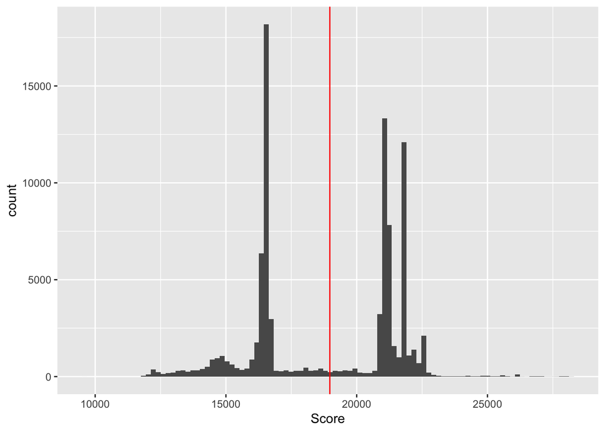

```r
library(ggplot2)
par(mfrow = c(2,1))
# Histogram
ggplot(leaderboard, aes(x=Score)) + geom_histogram(bins = 100)+geom_vline(xintercept=18973,color = "red")
```

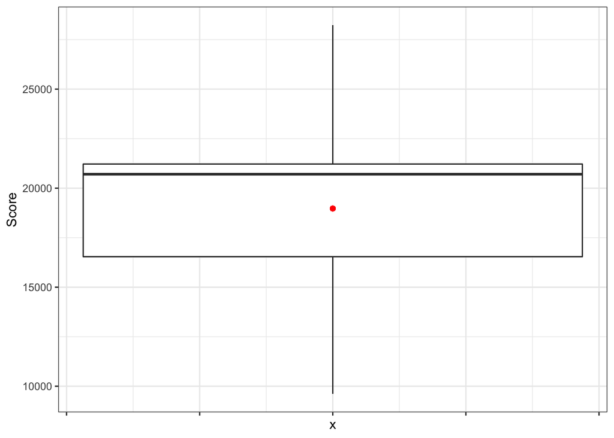

```r
#Boxplot
ggplot(leaderboard, aes(y=Score)) +
  geom_boxplot()+ theme_bw()+geom_point(aes(x=0,y=18973),color = "red")+theme(axis.text.x=element_blank())
```